# Practical Machine Learning report

James Longman

Friday, June 19, 2015

### Brief

This report explores the steps taken to build and test a model for predicting how users exercised based upon the measurements taken by their wearable technology.

### Exploratory analysis, cleaning and partitioning

The dimensions of the dataset is:

```
## [1] 19622   160
```

This is a large number of variables to consider but some basic analysis reveals that there are several things that can be done to remove variables that will prove to be poor predictors.

The following types of variables are not deemed to offer any predictive value:

- Columns with a large % of blank data
- Columns with a large % of NA values
- Columns with descriptive data (names, identifiers, times)

This is done with a combination of approaches including writing a function and some grep.

```r
oData <- oData[,-grep("window|time|kurtosis|skewness|amplitude|max_yaw|min_yaw",colnames(oData))]
idx <- apply(oData, 2, function(x) 0.95<(sum(is.na(x))/nrow(oData)))
oData <- oData[,!idx]
oData <- oData[,c(-1,-2)]
```

This leaves us with a reduced dataset with the dimensions of:

```r
dim(oData)
```

```
## [1] 19622    53
```

The dataset was then split in to training and testing partitions to allow for validation fo the model.

```r
idx <- createDataPartition(y=oData$classe, p=0.7, list=FALSE)
dTrain <- oData[idx,]
dTest <- oData[-idx,]
```

### Model training

Initially I tried a basic Tree model which did a reasonable job of predicting two of the classes when evaluated but with a poor overall accuracy this approach was discarded.

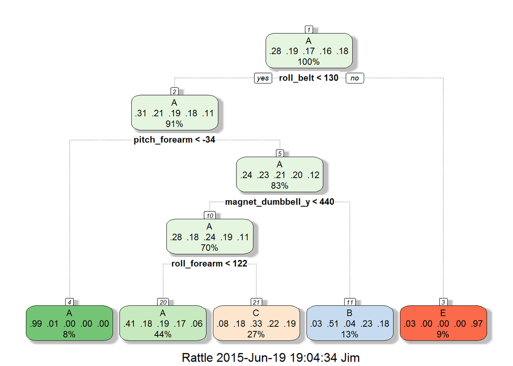

```
## CART
##
## 13737 samples
##    52 predictor
##     5 classes: 'A', 'B', 'C', 'D', 'E'
##
## No pre-processing
## Resampling: Bootstrapped (25 reps)
##
## Summary of sample sizes: 13737, 13737, 13737, 13737, 13737, 13737, ...
##
## Resampling results across tuning parameters:
##
##   cp          Accuracy   Kappa       Accuracy SD  Kappa SD
##   0.03600854  0.5072608  0.35661800  0.01880044   0.02808859
##   0.05970908  0.4317295  0.23423531  0.06488045   0.10906084
##   0.11545112  0.3370516  0.07902864  0.04063352   0.06060021
##
## Accuracy was used to select the optimal model using  the largest value.
## The final value used for the model was cp = 0.03600854.
```

Next I tried a random Forest approach. This generated a model with a much greater accuracy as can be seen from the confusion matrix.

```r
mForest <- randomForest(classe ~ ., data = dTrain, ntree = 1000)
mForest
```

```
##
## Call:
##  randomForest(formula = classe ~ ., data = dTrain, ntree = 1000)
##                Type of random forest: classification
##                      Number of trees: 1000
## No. of variables tried at each split: 7
##
##         OOB estimate of  error rate: 0.53%
## Confusion matrix:
##      A    B    C    D    E  class.error
## A 3903    2    0    0    1 0.0007680492
## B   17 2634    7    0    0 0.0090293454
## C    0   15 2378    3    0 0.0075125209
## D    0    0   20 2230    2 0.0097690941
## E    0    0    2    4 2519 0.0023762376
```

### Cross validation and error evaluation

With a good base accuracy for the model approach I employed k-fold cross validation to establish a decent approximation for the out-of-scope error rate.

I used three folds and looped through the model generation and prediction gathering which resulted in a prediction accuracy summary of:

```r
thisPrediction <- data.frame()
thisTestSet <- data.frame()

idxClasse <- grep("^classe$", colnames(dTrain))
flds <- createFolds(y=dTrain$classe, k = 3, list = TRUE, returnTrain = FALSE)

for (tempI in 1:length(flds)){
    tempTrain <- dTrain[-flds[[tempI]],]
    tempTest <- dTrain[flds[[tempI]],]

    thisModel <- randomForest(tempTrain$classe ~ ., data = tempTrain, ntree = 1000)

    tempResult <- as.data.frame(predict(thisModel, tempTest[,-idxClasse]))

    thisPrediction <- rbind(thisPrediction, tempResult)

    thisTestSet <- rbind(thisTestSet, as.data.frame(tempTest$classe))

}

thisResult <- cbind(thisPrediction, thisTestSet)
names(thisResult) <- c("Prediction", "Actual")
thisResult$correctPrediction <- thisResult$Actual == thisResult$Prediction

summary(thisResult$correctPrediction)
```

```
##    Mode   FALSE    TRUE    NA's
## logical     124   13613       0
```

Which calculates down to be a percentage error of:

```
## [1] 0.00910894
```

### Testing the model

Having established a method for creating a model which looked like it would provide highly accurate results and has been verified by cross validation I tested the model on the previously created dTest partition.

```
##
## thisPrediction    A    B    C    D    E
##              A 1673   14    0    0    0
##              B    1 1121   12    0    0
##              C    0    4 1010   14    0
##              D    0    0    4  950    6
##              E    0    0    0    0 1076
```

```
##    Mode   FALSE    TRUE    NA's
## logical      55    5830       0
```

```
## [1] 0.009433962
```

This set of results validated that the model predicts with a high degree of accuracy.